# QC: slan+ from tonsil (experiments 2 and 3)

Ramon Massoni-Badosa

2023-04-24

# 1 Introduction

The aim of this notebook is to perform a basic quality control of the slan+ cells from tonsil (experiments 2 and 3; subprojects: BCLLATLAS_162 and BCLLATLAS_164).

# 2 Pre-processing

## 2.1 Load packages

```r
library(Seurat)
library(tidyverse)
library(harmony)
library(scDblFinder)
library(here)
library(glue)
library(DT)
library(ggpubr)
```

# 3 Define parameters

```r
subprojects <- c("BCLLATLAS_162", "BCLLATLAS_164")

# Paths
path_to_cr <- here("scRNA-seq/1-cellranger_mapping/projects")
path_to_metadata <- here("scRNA-seq/1-cellranger_mapping/data/sequencing_metadata_slan_cells.csv")
path_to_save_obj <- here("scRNA-seq/results/R_objects/slancytes_revision/1.3.seurat_slan_cells_tonsil_filtered_experiments_2_and_3.rds")


# Functions
source(here("scRNA-seq/bin/utils.R"))


# Thresholds
min_lib_size <- 1250
min_n_genes <- 600
max_pct_mt <- 15
min_cells <- 4
```

# 4 Read data

```r
seq_metadata <- read_csv(path_to_metadata)
seq_metadata <- seq_metadata[seq_metadata$subproject %in% subprojects, ]
metrics_summaries <- map_df(1:nrow(seq_metadata), \(x) {
  subproject <- seq_metadata[x, "subproject", drop = TRUE]
  gem_id <- seq_metadata[x, "gem_id", drop = TRUE]
  path_to_metrics <- glue("{path_to_cr}/{subproject}/jobs/{gem_id}/{gem_id}/outs/metrics_summary.csv")
  df1 <- seq_metadata[x, c("gem_id", "library_name")]
  df2 <- read_csv(path_to_metrics)
  df <- bind_cols(df1, df2)
  df
})
DT::datatable(metrics_summaries, options = list(scrollX = TRUE))
```

|  | gem_id | library_name | Estimated Number of Cells | Mean Reads per Cell | Median Genes per Cell | Number of Reads | Valid Barcodes | Sequencing Saturation | Q30 Bases in Barcode | Q30 Bases in RNA Read | Q30 Bases in UMI | Reads Mapped to Genome | Reads Mapped Confidently to Genome | Reads Mapped Confidently to Intergenic Regions | Reads Mapped Confidently to Intronic Regions | Reads Mapped Confidently to Exonic Regions | Reads Mapped Confidently to Transcriptome | Reads Mapped Antisense to Gene | Fraction Reads in Cells | Total Genes Detected | Median UMI Counts per Cell |
| --- | --- | --- | --- | --- | --- | --- | --- | --- | --- | --- | --- | --- | --- | --- | --- | --- | --- | --- | --- | --- | --- |
| 1 | q0qp6qyu_nkrug5p0 | BCLL_10_MONO_DENDRITIC | 8969 | 38807 | 1604 | 348058417 | 97.6% | 58.7% | 96.9% | 94.6% | 96.1% | 97.6% | 91.1% | 4.6% | 21.2% | 65.3% | 62.1% | 2.0% | 89.6% | 27135 | 5032 |
| 2 | rssxkrxg_edqhwe1o | BCLL_10_SLANCYTES | 6951 | 33500 | 2144 | 232858528 | 97.7% | 27.2% | 96.9% | 95.3% | 96.2% | 96.3% | 91.3% | 3.1% | 21.0% | 67.2% | 64.1% | 1.6% | 91.6% | 25326 | 7043 |
| 3 | unhon9lu_srimqmkz | BCLL_8_MONO_DENDRITIC | 5679 | 36391 | 1474 | 206667239 | 97.5% | 45.7% | 97.0% | 95.3% | 96.3% | 95.8% | 90.5% | 5.4% | 27.8% | 57.3% | 53.1% | 3.0% | 51.2% | 23885 | 3851 |
| 4 | dy4as6b9_qb7g1ka6 | BCLL_8_SLANCYTES | 8114 | 30150 | 1527 | 244636517 | 96.9% | 45.9% | 97.0% | 94.8% | 96.2% | 95.1% | 85.2% | 5.8% | 29.1% | 50.3% | 46.6% | 2.4% | 72.3% | 24398 | 3740 |

```r
counts <- map(1:nrow(seq_metadata), \(x) {
  subproject <- seq_metadata[x, "subproject", drop = TRUE]
  gem_id <- seq_metadata[x, "gem_id", drop = TRUE]
  path_to_mat <- glue("{path_to_cr}/{subproject}/jobs/{gem_id}/{gem_id}/outs/filtered_feature_bc_matrix")
  mat <- Read10X(path_to_mat)
  mat
})
names(counts) <- seq_metadata$gem_id
map(counts, dim)
```

```
## $q0qp6qyu_nkrug5p0
## [1] 36601  8969
##
## $rssxkrxg_edqhwe1o
## [1] 36601  6951
##
## $unhon9lu_srimqmkz
## [1] 36601  5679
##
## $dy4as6b9_qb7g1ka6
## [1] 36601  8114
```

## 4.1 Create Seurat objects

```r
seurat_list <- map(names(counts), \(x) {
  seurat_obj <- CreateSeuratObject(counts = counts[[x]])
  seurat_obj$gem_id <- x
  seurat_obj$library_name <- seq_metadata[seq_metadata$gem_id == x, "library_name", drop = TRUE]
  seurat_obj <- RenameCells(seurat_obj, add.cell.id = x)
  seurat_obj$pct_mt <- PercentageFeatureSet(seurat_obj, pattern = "^MT-")
  seurat_obj$pct_ribo <- PercentageFeatureSet(seurat_obj, pattern = "(^RPL|^RPS)")
  seurat_obj
})
names(seurat_list) <- names(counts)
seurat <- purrr::reduce(seurat_list, merge)
rm(seurat_list)
gc()
```

```
##             used   (Mb) gc trigger   (Mb)  max used   (Mb)
## Ncells  10687077  570.8   19305932 1031.1  14331678  765.4
## Vcells 279707477 2134.0  603326440 4603.1 503263074 3839.6
```

```r
seurat
```

```
## An object of class Seurat
## 36601 features across 29713 samples within 1 assay
## Active assay: RNA (36601 features, 0 variable features)
```

# 5 Cell filtering

## 5.1 Library Size

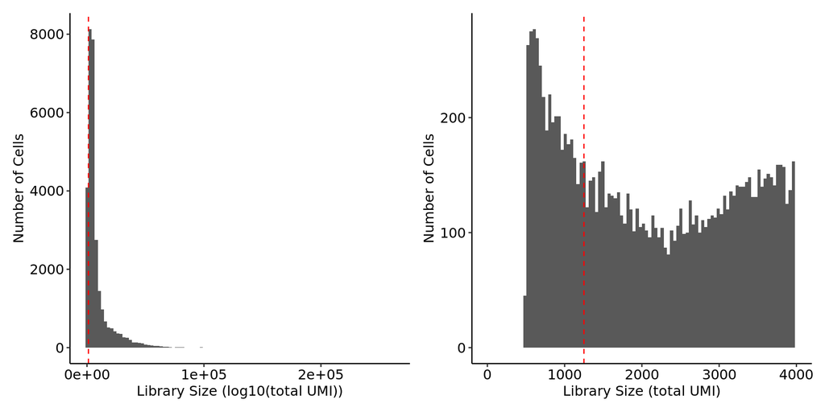

```r
lib_size_hist <- seurat@meta.data %>%
  plot_histogram_qc(x = "nCount_RNA", x_lab = "Library Size (log10(total UMI))") +
  geom_vline(xintercept = min_lib_size, linetype = "dashed", color = "red")
lib_size_hist2 <- lib_size_hist +
    scale_x_continuous(limits = c(0, 4000)) +
    xlab("Library Size (total UMI)") +
    theme_pubr()
lib_size_hist + lib_size_hist2
```

## 5.2 Number of detected genes

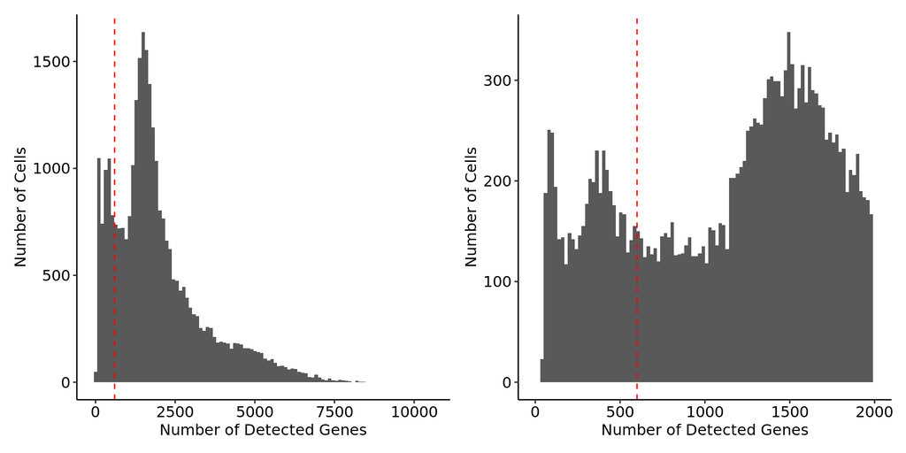

```r
n_genes_hist1 <- seurat@meta.data %>%
  plot_histogram_qc(x = "nFeature_RNA", x_lab = "Number of Detected Genes") +
  geom_vline(xintercept = min_n_genes, linetype = "dashed", color = "red")
n_genes_hist2 <- n_genes_hist1 +
  scale_x_continuous(limits = c(0, 2000))
n_genes_hist1 + n_genes_hist2
```

## 5.3 Fraction of mitochondrial expression

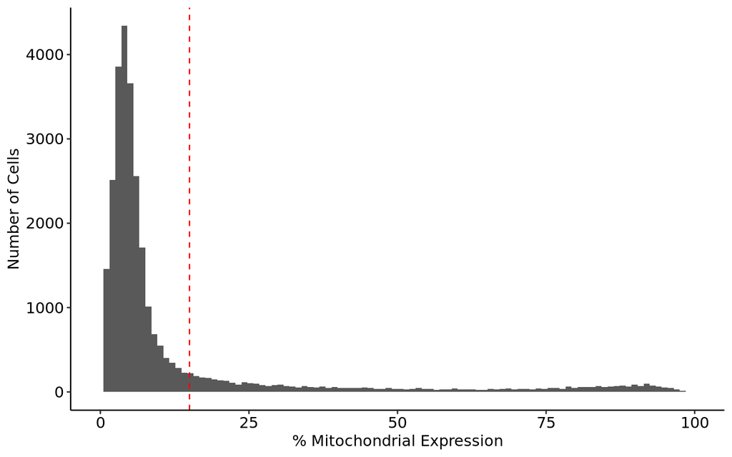

```r
pct_mt_hist <- seurat@meta.data %>%
  plot_histogram_qc(x = "pct_mt", x_lab = "% Mitochondrial Expression") +
  geom_vline(xintercept = max_pct_mt, linetype = "dashed", color = "red") +
  scale_x_continuous(limits = c(0, 100))
pct_mt_hist
```

## 5.4 Fraction of ribosomal expression

Let us also calculate and visualize the proportion of ribosomal expression:

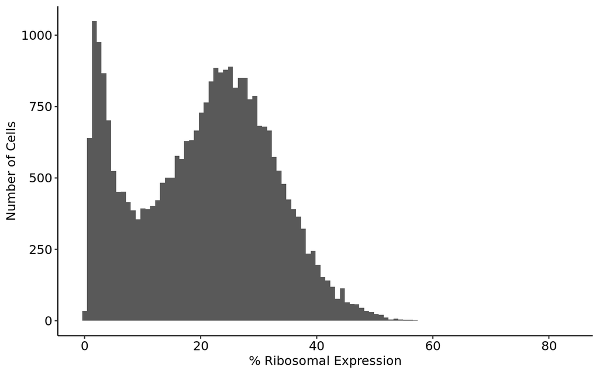

```r
pct_ribosomal_hist <- seurat@meta.data %>%
  plot_histogram_qc(x = "pct_ribo", x_lab = "% Ribosomal Expression")
pct_ribosomal_hist
```

## 5.5 Joint QC metrics

It is important to assess how these variables covary, since metabolically active cells might also have a high mitochondrial expression:

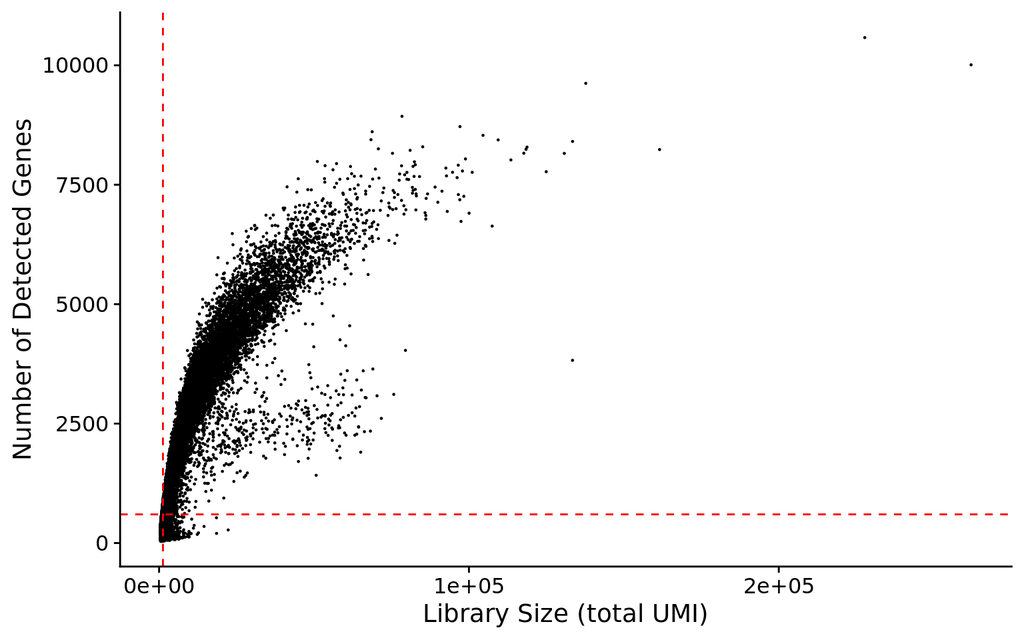

```r
# number of detected genes VS library size
n_genes_vs_lib_size <- FeatureScatter(
  seurat,
  feature1 = "nCount_RNA",
  feature2 = "nFeature_RNA",
  pt.size = 0.15,
  cols = rep("black", length(levels(Idents(seurat))))
)
n_genes_vs_lib_size <- n_genes_vs_lib_size +
  labs(x = "Library Size (total UMI)", y = "Number of Detected Genes") +
  theme(legend.position = "none", plot.title = element_blank())
n_genes_vs_lib_size +
  geom_vline(xintercept = min_lib_size, linetype = "dashed", color = "red") +
  geom_hline(yintercept = min_n_genes, linetype = "dashed", color = "red")
```

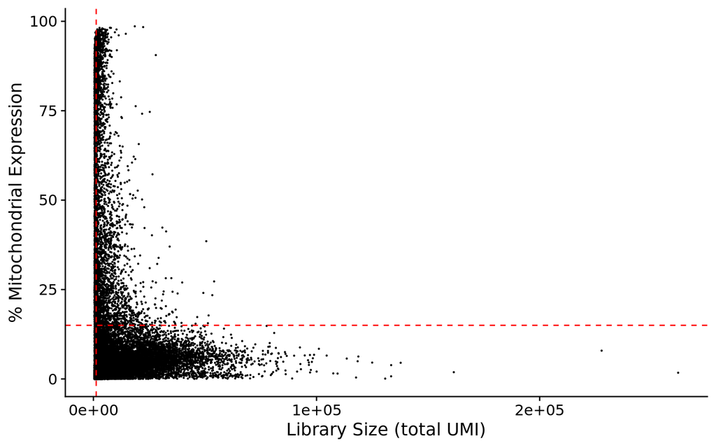

```r
# % mitochondrial expression VS library size
pct_mt_vs_lib_size <- FeatureScatter(
  seurat,
  feature1 = "nCount_RNA",
  feature2 = "pct_mt",
  pt.size = 0.15,
  cols = rep("black", length(levels(Idents(seurat))))
)
pct_mt_vs_lib_size <- pct_mt_vs_lib_size +
  labs(x = "Library Size (total UMI)", y = "% Mitochondrial Expression") +
  theme(legend.position = "none", plot.title = element_blank())
pct_mt_vs_lib_size +
  geom_vline(xintercept = min_lib_size, linetype = "dashed", color = "red") +
  geom_hline(yintercept = max_pct_mt, linetype = "dashed", color = "red")
```

Let’s assess how the 3 variables distribute across both samples:

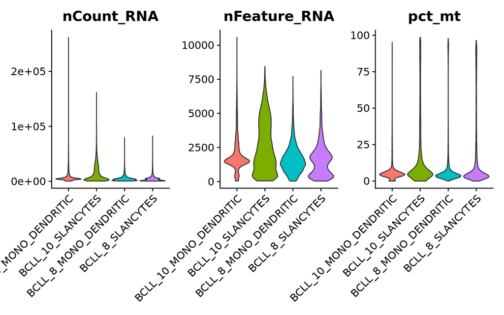

```r
VlnPlot(
  seurat,
  features = c("nCount_RNA", "nFeature_RNA", "pct_mt"),
  group.by = "library_name",
  pt.size = 0
) &
  theme(axis.title.x = element_blank())
```

## 5.6 Subset empty droplets and lysed cells

```r
metadata_before_qc <- seurat@meta.data
is_low_quality <- with(seurat@meta.data,
  nCount_RNA < min_lib_size |
  nFeature_RNA < min_n_genes |
  pct_mt > max_pct_mt
)
table(is_low_quality)
```

```
## is_low_quality
## FALSE  TRUE
## 22412  7301
```

```r
seurat
```

```
## An object of class Seurat
## 36601 features across 29713 samples within 1 assay
## Active assay: RNA (36601 features, 0 variable features)
```

```r
(seurat <- seurat[, !is_low_quality])
```

```
## An object of class Seurat
## 36601 features across 22412 samples within 1 assay
## Active assay: RNA (36601 features, 0 variable features)
```

```r
metadata_after_qc <- seurat@meta.data
```

## 5.7 QC summary table

```r
qc_before <- metadata_before_qc %>%
  group_by(gem_id) %>%
  summarise(num_cells_before_qc = n())
qc_before
```

```
## # A tibble: 4 × 2
##   gem_id            num_cells_before_qc
##   <chr>                           <int>
## 1 dy4as6b9_qb7g1ka6                8114
## 2 q0qp6qyu_nkrug5p0                8969
## 3 rssxkrxg_edqhwe1o                6951
## 4 unhon9lu_srimqmkz                5679
```

```r
qc_after <- metadata_after_qc %>%
  group_by(gem_id) %>%
  summarise(
    num_cells_after_qc = n(),
    average_library_size = mean(nCount_RNA),
    average_num_detected_genes = mean(nFeature_RNA),
    average_mitochondrial_fraction = mean(pct_mt)
  )
DT::datatable(qc_after, options = list(scrollX = TRUE))
```

|  | gem_id | num_cells_after_qc | average_library_size | average_num_detected_genes | average_mitochondrial_fraction |
| --- | --- | --- | --- | --- | --- |
| 1 | dy4as6b9_qb7g1ka6 | 5350 | 7374.31345794393 | 2206.65196261682 | 4.34941608684135 |
| 2 | q0qp6qyu_nkrug5p0 | 7943 | 9472.98627722523 | 2149.25443786982 | 4.96091541152694 |
| 3 | rssxkrxg_edqhwe1o | 4488 | 18708.4795008913 | 3235.37923351159 | 5.9105238427648 |
| 4 | unhon9lu_srimqmkz | 4631 | 6048.12157201468 | 1867.87302958324 | 4.52257475216284 |

# 6 Doublets

We use [scDblFinder](http://bioconductor.org/books/3.15/OSCA.advanced/doublet-detection.html#computing-doublet-densities):

```r
seurat <- NormalizeData(seurat)
seurat <- FindVariableFeatures(seurat)
sce <- as.SingleCellExperiment(seurat)
dbl_densities <- computeDoubletDensity(
  sce,
  dims = 30,
  subset.row = VariableFeatures(seurat)
)
summary(dbl_densities)
```

```
##    Min. 1st Qu.  Median    Mean 3rd Qu.    Max.
##  0.0000  0.0800  0.2400  0.4141  0.5400 16.7200
```

```r
seurat$doublet_score <- dbl_densities
```

# 7 Gene filtering

According to [Luecken MD et al.](https://www.embopress.org/doi/10.15252/msb.20188746): “A guideline to setting this threshold is to use the minimum cell cluster size that is of interest and leaving some leeway for dropout effects. For example, filtering out genes expressed in fewer than 20 cells may make it difficult to detect cell clusters with fewer than 20 cells. For datasets with high dropout rates, this threshold may also complicate the detection of larger clusters. The choice of threshold should scale with the number of cells in the dataset and the intended downstream analysis.”

## 7.1 Set threshold

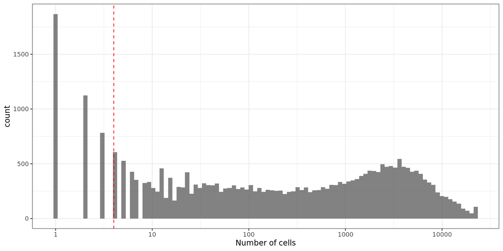

```r
n_cells <- Matrix::rowSums(seurat[["RNA"]]@counts > 0)
gene_qc <- n_cells %>%
  as.data.frame() %>%
  ggplot(aes(n_cells)) +
    geom_histogram(bins = 100, alpha = 0.75) +
    scale_x_log10("Number of cells") +
    theme_bw()
gene_qc +
  geom_vline(xintercept = min_cells, linetype = "dashed", color = "red")
```

## 7.2 Plot genes with highest expression

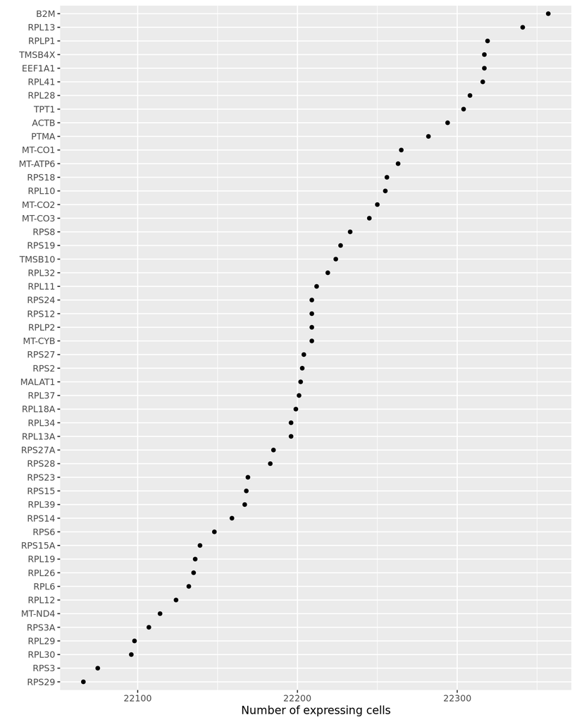

```r
top_50_genes <- sort(n_cells, decreasing = TRUE)[1:50]
top_50_genes_df <- data.frame(
  gene = names(top_50_genes),
  n_cells = top_50_genes
)
top_50_genes_df %>%
  ggplot(aes(fct_reorder(gene, n_cells), n_cells)) +
    geom_point() +
    labs(x = "", y = "Number of expressing cells") +
    coord_flip()
```

## 7.3 Filter

```r
kept_genes <- rownames(seurat)[n_cells > min_cells]
table(n_cells > min_cells)
```

```
##
## FALSE  TRUE
## 11518 25083
```

```r
(seurat <- subset(seurat, features = kept_genes))
```

```
## An object of class Seurat
## 25083 features across 22412 samples within 1 assay
## Active assay: RNA (25083 features, 1994 variable features)
```

# 8 Filter out contaminating cells

We observed in the web_summary.html file that there are contaminating B and T cells in our dataset. That is expected, because they compose over 90% of the tonsil. Thus, let us filter them out in silico:

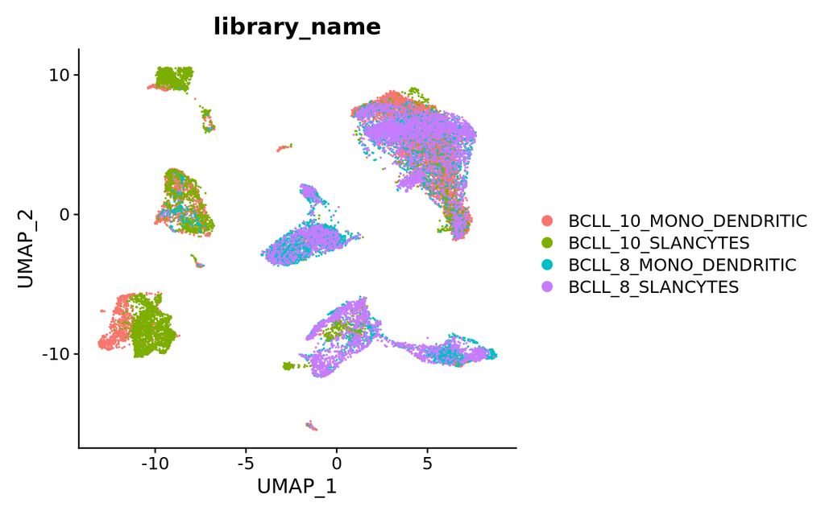

```r
seurat <- seurat %>%
  NormalizeData() %>%
  FindVariableFeatures() %>%
  ScaleData() %>%
  RunPCA() %>%
  RunHarmony(reduction = "pca", group.by.vars = "gem_id") %>%
  RunUMAP(dims = 1:20, reduction = "harmony")
DimPlot(seurat, group.by = "library_name")
```

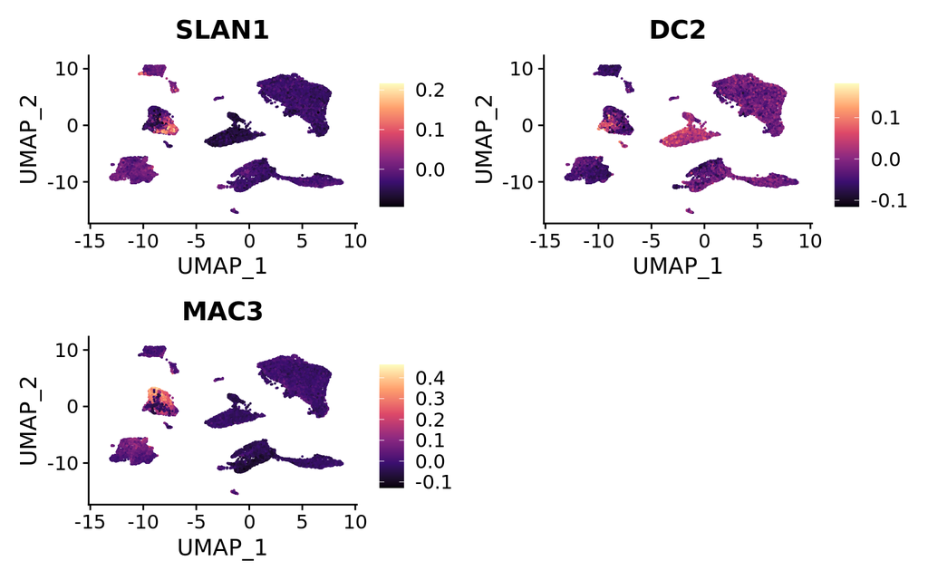

```r
# FeaturePlot(seurat, c("CD79A", "CD3D", "LYZ"), split.by = "library_name")
# seurat <- FindNeighbors(seurat, dims = 1:20, reduction = "harmony")
# seurat <- FindClusters(seurat, resolution = 0.1)
# DimPlot(seurat)
# markers_l <- map(levels(Idents(seurat)), \(x) {
#   df <- FindMarkers(seurat, ident.1 = x, only.pos = TRUE, logfc.threshold = 0.5)
#   df
# })
# names(markers_l) <- levels(Idents(seurat))
# for (x in names(markers_l)) {
#   print(x)
#   print(head(markers_l[[x]], 15))
# }

slan_markers <- read.delim(here("data/raw_data_figures/BA2020Faseb_SLANmarkers.txt"))
sel_genes <- slan_markers$Gene[slan_markers$Gene %in% rownames(seurat)]
seurat <- AddModuleScore(
  seurat,
  features = list(
    SLAN = slan_markers$Gene[slan_markers$CellType == "SLAN"],
    DC = slan_markers$Gene[slan_markers$CellType == "DC"],
    MAC = slan_markers$Gene[slan_markers$CellType == "MAC"]
  ),
  name = c("SLAN", "DC", "MAC")
)
FeaturePlot(seurat, c("SLAN1", "DC2", "MAC3")) &
  scale_color_viridis_c(option = "magma")
```

```r
# excluded_clusters <- c("0", "2", "3", "5", "7")
# seurat <- seurat[, !(seurat$seurat_clusters %in% excluded_clusters)]
# DimPlot(seurat)
# seurat
```

NOTE: We will not discard cells from non-myeloid populations at this stage. Instead, in the next notebook we will map the cells to our tonsil reference and keep only those mapped to myeloid cells with high accuracy.

# 9 Save

```r
saveRDS(seurat, path_to_save_obj)
```